# Pink Rockfish

*Sebastes eos*

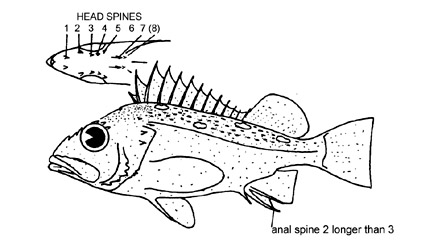

**Body color:** Faded pink w/ vague green streaks and small blotches on back; 3 to 5 whitish blotches on back; fins yellow-pink.

**Peritoneum color:** dark or light **Shape between eyes:** concave

**Counts:** D:XIII,11-13, Ar:5-7, P1:17-18, GR:26-31, LLp:34-42, LLs:?-?, V:26

**Occurence:** Oregon - Baja California

**Depth:** 366 meters **Size:** 56 cm **Species code:** 30230

**Similar species:**

- *Greenblotched rockfish* - pectoral rays typically 17 (typically 18 in Pink RF); gillrakers typically 30-34 (26-31 in Pink RF); spines absent on lower edge of operculum (1-2 in Pink RF); upper gillrakers not rudimentary (rudimentary in Pink RF)
- *Greenspotted rockfish* - body w/ round green spots; upper gillrakers not rudimentary (rudimentary in Pink RF); scales on lower jaw few or absent (lower jaw scaled in Pink RF); gillrakers 31-36 (26-31 in Pink RF)
- *Rosethorn rockfish* - pectoral rays typically 16 (typically 17-18 in Pink RF); upper gillrakers not rudimentary (rudimentary in Pink RF)
- *Freckled rockfish* - prominent knobs bordering notch in upper jaw (absent in Pink RF); back w/ dense green freckling; gillrakers 34-39 (26-31 in Pink RF); upper gillrakers not rudimentary (rudimentary in Pink RF)
- *Swordspine rockfish* - lower jaw projects (jaws equal in Rosy RF); symphyseal knob prominent (absent or small in Rosy RF); gillrakers 34-40 (26-31 in Pink RF)
- *Rosy rockfish* - body red, mottled w/ purple (green spots and streaks in Pink RF)

Back to Group

**Corrections:** If you see mistakes or want to suggest changes, please create an [issue](https://github.com/zoyafuso-NOAA/RACE_Survey_App/issues) on the source repository or

*reach out to Liz Dawson (Liz.Dawson AT noaa.gov).*